# Toronto Blue Jays – Hitting Development Overview

← League overview

**2026 season · 19 hitters tracked (7 qualified, 5 small samples)**

Weighted by swings, Jays hitters average **71.2 mph** of bat speed vs 72.1 mph for MLB, with a squared-up rate of 25.5% vs 24.8%. Profiles: 6 contact hitter, 4 under-powered, 5 balanced, 4 raw power. **Top 3 development priorities:** Tyler Heineman, Ernie Clement, Andrés Giménez.

## Roster map

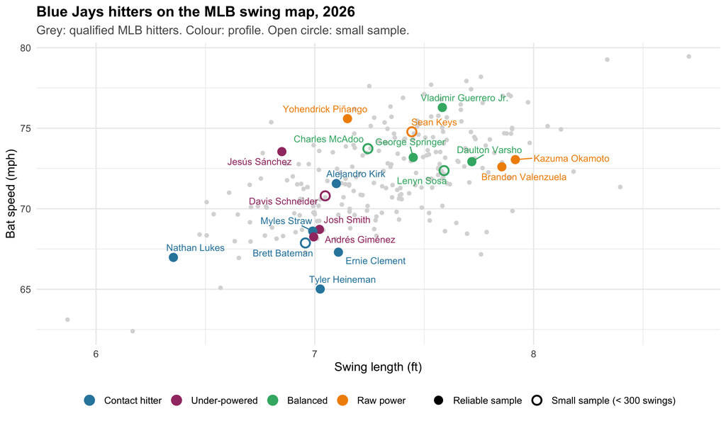

## Development priorities

| # | Player | Swings | Profile | Main strength | Main weakness | xwOBA (pct) / wOBA | Priority lever | Score | Priority |
| --- | --- | --- | --- | --- | --- | --- | --- | --- | --- |
| 1 | Tyler Heineman | 321 | Contact hitter | Contact quality (69) | Bat speed (1) | 0.236 (1) / 0.204 | Add bat speed, protect contact | 99 | Top 3 |
| 2 | Ernie Clement | 959 | Contact hitter | Contact quality (96) | Bat speed (3) | 0.258 (1) / 0.284 | Add bat speed, protect contact | 98 | Top 3 |
| 3 | Andrés Giménez | 901 | Under-powered | Contact quality (44) | Bat speed (6) | 0.276 (5) / 0.286 | Add bat speed (physical screen first) | 94 | Top 3 |
| 4 | Josh Smith | 407 | Under-powered | Whiff avoidance (58) | Bat speed (11) | 0.276 (5) / 0.275 | Add bat speed (physical screen first) | 92 | Next |
| 5 | Nathan Lukes | 758 | Contact hitter | Whiff avoidance (86) | Bat speed (2) | 0.293 (14) / 0.317 | Add bat speed, protect contact | 92 | Next |
| 6 | Myles Straw | 431 | Contact hitter | Contact quality (97) | Barrels (7) | 0.292 (12) / 0.288 | Add bat speed, protect contact | 89 | Next |
| 7 | Daulton Varsho | 905 | Balanced | Whiff avoidance (62) | Contact quality (16) | 0.283 (8) / 0.281 | Contact quality & swing efficiency | 88 | Next |
| 8 | Brandon Valenzuela | 478 | Raw power | Bat speed (56) | Contact quality (9) | 0.313 (35) / 0.303 | Contact quality & swing efficiency | 78 | Next |
| 9 | Yohendrick Piñango | 317 | Raw power | Bat speed (89) | Contact quality (18) | 0.309 (31) / 0.309 | Contact quality & swing efficiency | 76 | Next |
| 10 | Alejandro Kirk | 468 | Contact hitter | Whiff avoidance (92) | Barrels (12) | 0.308 (30) / 0.333 | Add bat speed, protect contact | 64 | Next |
| 11 | Kazuma Okamoto | 1112 | Raw power | Barrels (88) | Whiff avoidance (12) | 0.328 (59) / 0.332 | Contact quality & swing efficiency | 56 | Next |
| 12 | Jesús Sánchez | 536 | Under-powered | Barrels (71) | Whiff avoidance (24) | 0.321 (47) / 0.311 | Add bat speed (physical screen first) | 42 | Next |
|  | Lenyn Sosa | 217 ⚠ | Balanced | Whiff avoidance (56) | Barrels (25) | 0.249 (1) / 0.214 | Swing decisions (chase less) | 99 | Watch |
|  | Sean Keys | 136 ⚠ | Raw power | Bat speed (83) | Contact quality (3) | 0.262 (1) / 0.247 | Contact quality & swing efficiency | 98 | Watch |
|  | Charles McAdoo | 167 ⚠ | Balanced | Bat speed (70) | Contact quality (8) | 0.289 (11) / 0.303 | Contact quality & swing efficiency | 90 | Watch |
|  | Brett Bateman | 260 ⚠ | Contact hitter | Whiff avoidance (96) | Barrels (2) | 0.312 (34) / 0.368 | Add bat speed, protect contact | 82 | Watch |
|  | Davis Schneider | 230 ⚠ | Under-powered | Barrels (71) | Whiff avoidance (4) | 0.287 (11) / 0.290 | Add bat speed (physical screen first) | 79 | Watch |
|  | Vladimir Guerrero Jr. | 922 | Balanced | Bat speed (93) | Barrels (39) | 0.331 (63) / 0.305 | Maintain; decisions & timing |  | Maintain |
|  | George Springer | 863 | Balanced | Whiff avoidance (66) | Barrels (35) | 0.306 (27) / 0.320 | Maintain; decisions & timing |  | Maintain |

Numbers in brackets are MLB percentiles (1–100) vs qualified hitters. wOBA = actual production. **Score** (0–100) = average of (100 − xwOBA percentile) and (100 − percentile of the metric targeted by the lever): the lower the production and the clearer the targeted weakness, the higher the priority. Hitters with a reliable sample and a clear lever are ranked; the **Top 3** are highlighted. **Watch**: fewer than 300 competitive swings, early signals only (⚠). **Maintain**: balanced profile or xwOBA at the 70th percentile or above. Click a name to open the individual report.

## Team vs MLB

| Metric | Blue Jays | MLB | Difference |
| --- | --- | --- | --- |
| Bat speed (mph) | 71.2 | 72.1 | -0.9 |
| Swing length (ft) | 7.28 | 7.32 | -0.05 |
| Squared-up / swing | 25.5% | 24.8% | +0.7 pts |
| Whiff / swing | 20.8% | 23.3% | -2.5 pts |
| Chase rate | 33.8% | 30.9% | +3.0 pts |
| Walk % | 7.3% | 8.8% | -1.5 pts |
| Strikeout % | 19.2% | 22.2% | -3.1 pts |
| xwOBA | 0.296 | 0.315 | -0.020 |

Averages weighted by competitive swings, all tracked hitters.

## Year-over-year changes

| Player | Bat speed (mph) | Squared-up / swing | xwOBA |
| --- | --- | --- | --- |
| Jesús Sánchez | 75.8 → 73.5 (-2.3) | 23.2% → 22.6% (-0.6 pts) | 0.323 → 0.321 (-0.002) |
| Myles Straw | 67.0 → 68.6 (+1.6) | 33.2% → 35.0% (+1.9 pts) | 0.295 → 0.292 (-0.003) |
| Nathan Lukes | 68.0 → 67.0 (-1.0) | 30.6% → 29.4% (-1.2 pts) | 0.315 → 0.293 (-0.022) |
| Ernie Clement | 67.6 → 67.3 (-0.3) | 37.6% → 34.3% (-3.3 pts) | 0.289 → 0.258 (-0.031) |
| Andrés Giménez | 69.3 → 68.3 (-1.0) | 24.2% → 24.5% (+0.4 pts) | 0.308 → 0.276 (-0.032) |
| Josh Smith | 69.0 → 68.7 (-0.3) | 27.7% → 23.3% (-4.4 pts) | 0.310 → 0.276 (-0.034) |
| Davis Schneider | 71.5 → 70.8 (-0.7) | 22.6% → 20.9% (-1.7 pts) | 0.323 → 0.287 (-0.036) |
| Tyler Heineman | 66.1 → 65.0 (-1.1) | 24.6% → 26.8% (+2.2 pts) | 0.273 → 0.236 (-0.037) |
| Daulton Varsho | 75.6 → 72.9 (-2.7) | 20.4% → 20.4% (+0.1 pts) | 0.327 → 0.283 (-0.044) |
| Alejandro Kirk | 72.5 → 71.6 (-0.9) | 31.8% → 31.6% (-0.1 pts) | 0.359 → 0.308 (-0.051) |
| Vladimir Guerrero Jr. | 76.7 → 76.3 (-0.4) | 29.8% → 26.4% (-3.4 pts) | 0.384 → 0.331 (-0.053) |
| Lenyn Sosa | 72.5 → 72.4 (-0.2) | 27.0% → 23.5% (-3.5 pts) | 0.326 → 0.249 (-0.077) |
| George Springer | 73.8 → 73.2 (-0.6) | 24.5% → 24.2% (-0.3 pts) | 0.404 → 0.306 (-0.098) |

2025 values may come from another team for players acquired since. Sorted by change in xwOBA.

Data: Baseball Savant, public Statcast data (bat tracking, expected stats, exit velocity). Profiles, percentiles and model are based on the 232 qualified MLB hitters in 2026 (570+ competitive swings); other hitters are placed against that reference. Internal biomechanics and force-plate data would turn these leads into measured diagnoses. Report: Hugo Leligny.

Hugo Leligny · Sport Scientist & Performance Analyst  
Measure → Analyze → Decide → Train → Monitor → Adapt ↻  
hugoleligny14@gmail.com · [GitHub](https://github.com/hugollel/blue-jays-hitting)